# Play with Gamma

OK, I figured out some of what was happening for you with the gamma. Even though I was mostly convinced that I had things coded right, what I did was clarify the shape= and scale= in the code, and then played with it both ways.

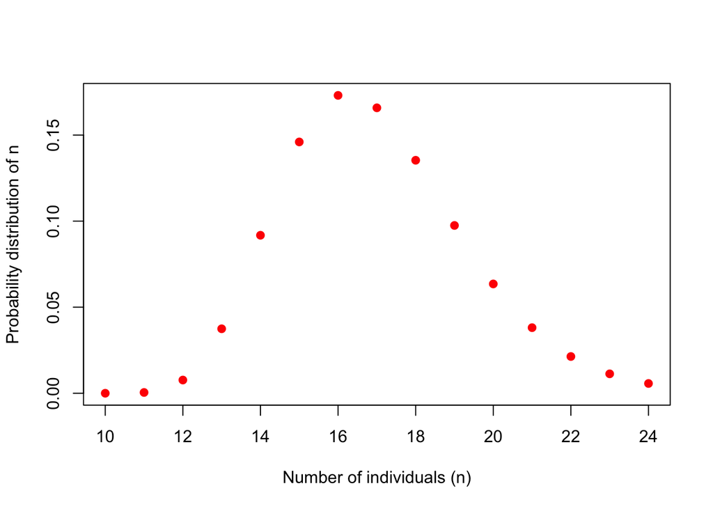

However when this is reversed you get somthing quite different:

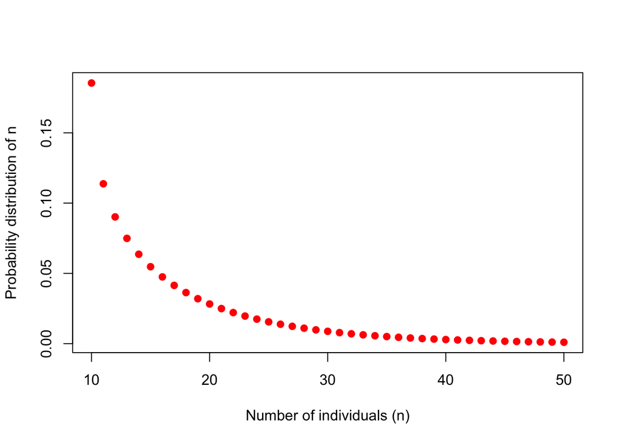

At first this is intuitively appealing because hey! The minimum number of individuals is highest probability, diminishing probability as you head to larger sample sizes.

However when haplotype diversity is low - remember this is when we have little information - you obtain something that doesn’t intuitively make sense, you get a huge probability for the number of individuals being equal to number of haplotypes and it drops off very quickly.

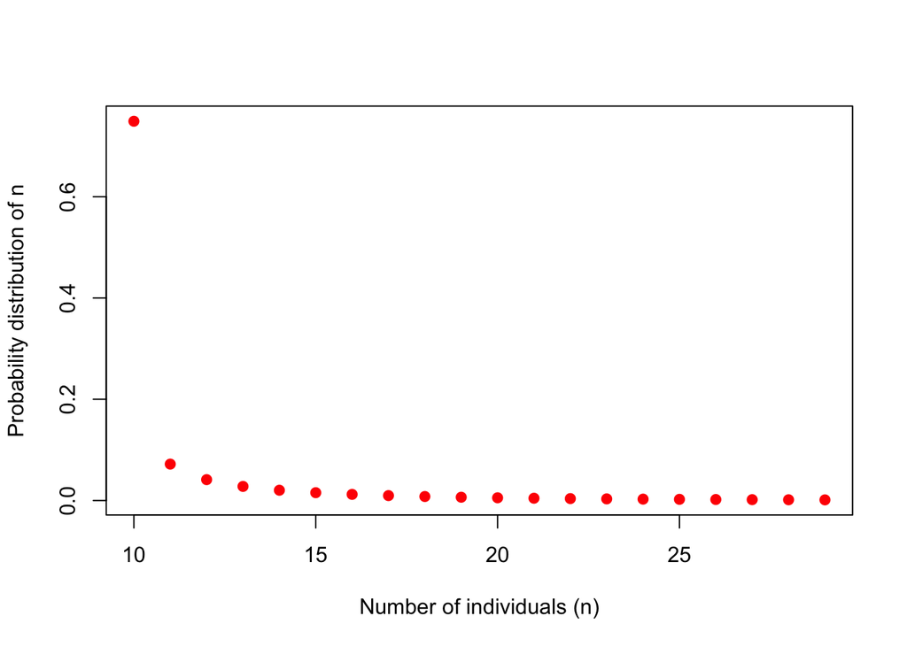

and in the extreme we recover the exact match:

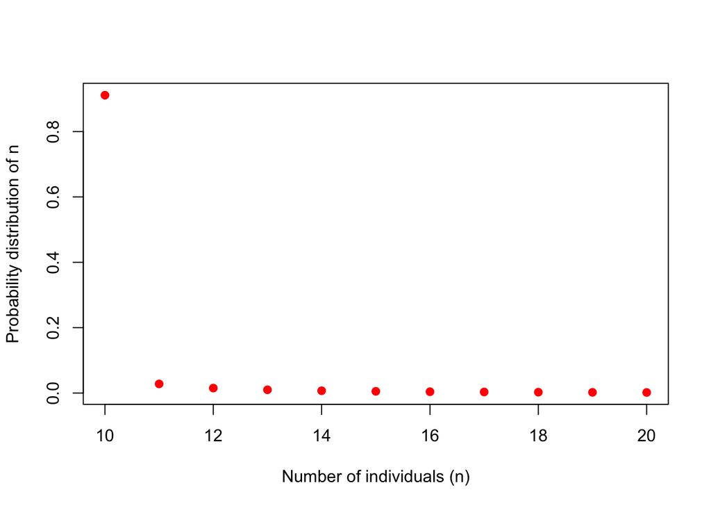

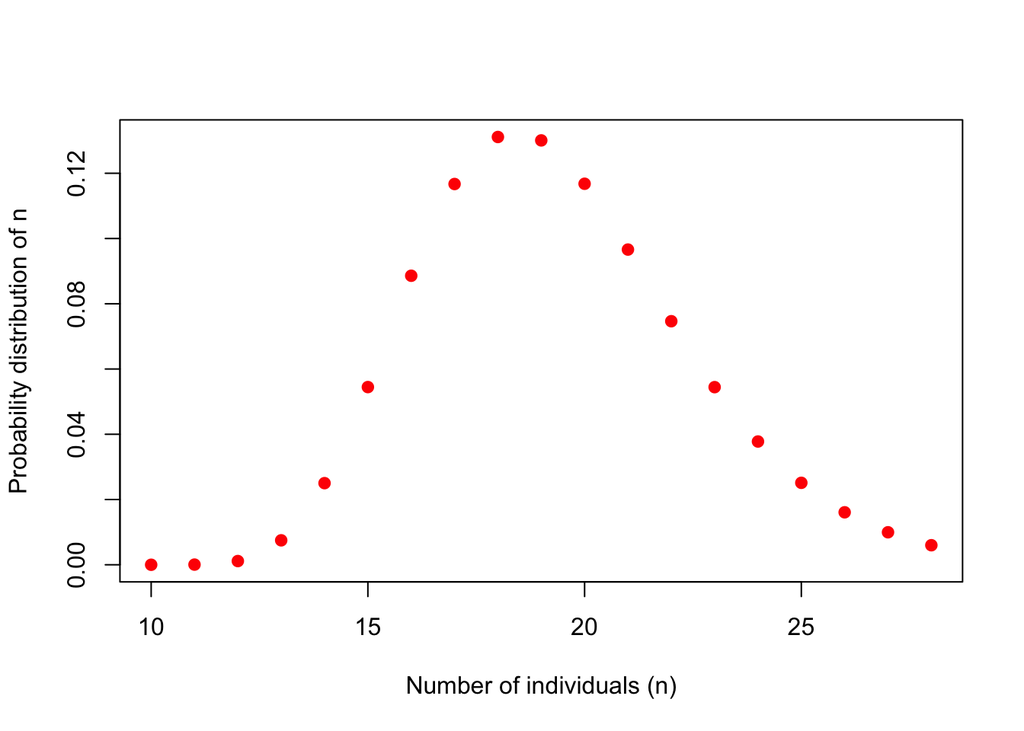

Now remember so far this is not exactly how I had written it. By omitting shape = and scale=, I think it was mis-parameterizing so far (sad face)??

Because

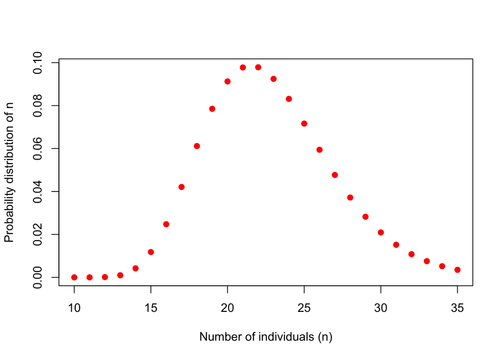

and

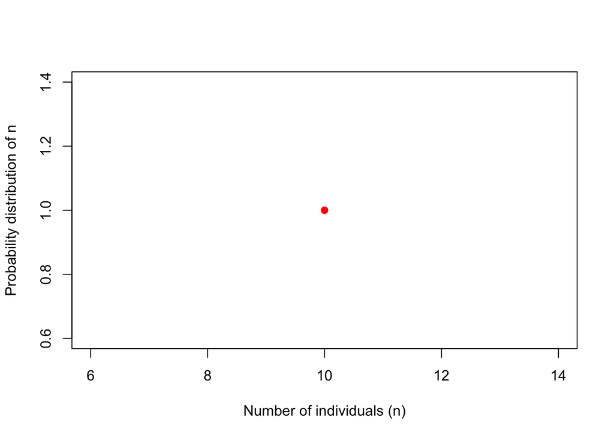

these last 2 plots were what you were puzzling over, when those parameters were reversed. In fact the second one is invariant to what “hapdiv” is, so clearly without stating those scale, shape values it is inserting those numbers into the wrong slots (at least, when reversed).

So what should we be using then?